# Pertemuan-2-kuliah

# Import Library

```r
library(readxl)
library(lmtest)
library(orcutt)
library(HoRM)
```

# Import Data

```r
ipmbkt <- read_excel("D:\\Doc Helmi\\Semester 5\\MPDW\\mpdw\\pertemuan 3\\ipmbukittingi.xlsx")
ipmbkt
```

```
## # A tibble: 15 × 2
##    Tahun   IPM
##    <dbl> <dbl>
##  1  2010  76.1
##  2  2011  76.3
##  3  2012  76.9
##  4  2013  77.7
##  5  2014  78.0
##  6  2015  78.7
##  7  2016  79.1
##  8  2017  79.8
##  9  2018  80.1
## 10  2019  80.7
## 11  2020  80.6
## 12  2021  80.7
## 13  2022  81.4
## 14  2023  81.8
## 15  2024  82.5
```

```r
#Membentuk objek time series
ipmbkt.ts<-ts(ipmbkt$IPM)
ipmbkt.ts
```

```
## Time Series:
## Start = 1
## End = 15
## Frequency = 1
##  [1] 76.12 76.30 76.92 77.67 78.02 78.72 79.11 79.80 80.11 80.71 80.58 80.70
## [13] 81.42 81.78 82.51
```

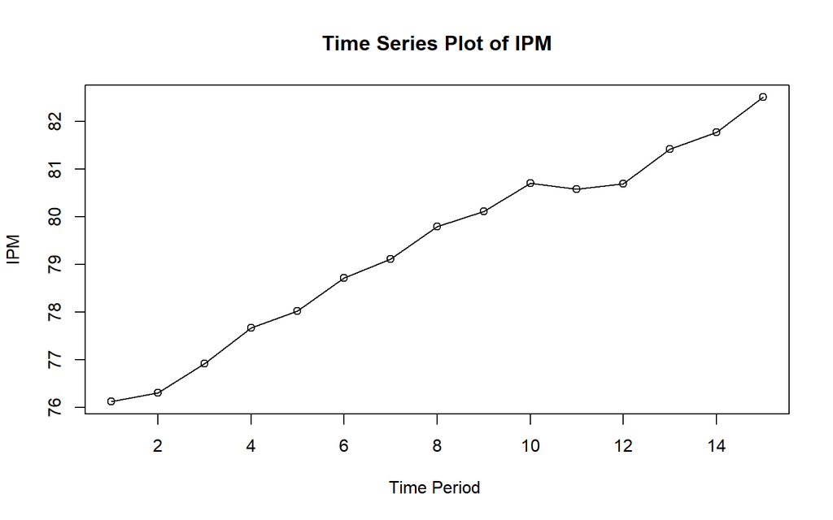

```r
#Membuat plot time series
ts.plot(ipmbkt.ts, xlab="Time Period ", ylab="IPM", main= "Time Series Plot of IPM")
points(ipmbkt.ts)
```

Terlihat dari plot terdapat tren pada data IPM Bukittinggi.

# Pemodelan Regresi

```r
modelipm <- lm(IPM ~ Tahun, data = ipmbkt)
summary(modelipm)
```

```
##
## Call:
## lm(formula = IPM ~ Tahun, data = ipmbkt)
##
## Residuals:
##      Min       1Q   Median       3Q      Max
## -0.44881 -0.19467 -0.00656  0.21939  0.45326
##
## Coefficients:
##               Estimate Std. Error t value Pr(>|t|)
## (Intercept) -820.28937   35.34857  -23.21 5.78e-12 ***
## Tahun          0.44604    0.01753   25.45 1.78e-12 ***
## ---
## Signif. codes:  0 '***' 0.001 '**' 0.01 '*' 0.05 '.' 0.1 ' ' 1
##
## Residual standard error: 0.2933 on 13 degrees of freedom
## Multiple R-squared:  0.9803, Adjusted R-squared:  0.9788
## F-statistic: 647.8 on 1 and 13 DF,  p-value: 1.781e-12
```

Model regresi linier sederhana menunjukkan bahwa IPM meningkat seiring bertambahnya tahun dengan laju sekitar 0.446 poin per tahun. Model ini sangat baik (R² ≈ 98%) sehingga bisa digunakan untuk prediksi IPM berdasarkan tahun. Dengan Persamaan Regresi sebagai berikut :
$$IPM = -820.289 + 0.446 \times Tahun$$
Namun Untuk memastikan validitas model, perlu dilakukan diagnostik sisaan untuk memeriksa asumsi klasik regresi, terutama autokorelasi.

# Diagnostik

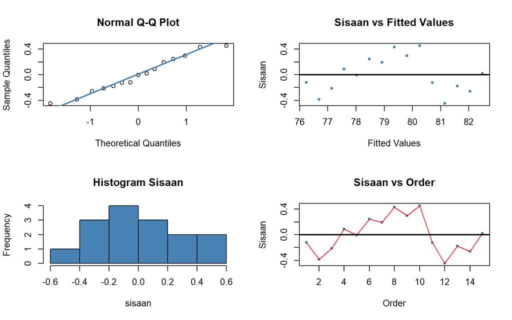

```r
# Sisaan dan fitted value
sisaan <- residuals(modelipm)
fitValue <- predict(modelipm)

# Diagnostik dengan eksploratif
par(mfrow = c(2,2))

# QQ-plot
qqnorm(sisaan)
qqline(sisaan, col = "steelblue", lwd = 2)

# Sisaan vs Fitted Values
plot(fitValue, sisaan, col = "steelblue", pch = 20,
     xlab = "Fitted Values", ylab = "Sisaan",
     main = "Sisaan vs Fitted Values")
abline(h = 0, lwd = 2)

# Histogram sisaan
hist(sisaan, col = "steelblue", main = "Histogram Sisaan")

# Sisaan vs Order (urutan pengamatan)
plot(seq_along(sisaan), sisaan, col = "steelblue", pch = 20,
     xlab = "Order", ylab = "Sisaan",
     main = "Sisaan vs Order")
lines(seq_along(sisaan), sisaan, col = "red")
abline(h = 0, lwd = 2)
```

Hasil diagnostik secara eksplorasi menunjukkan bahwa model regresi memenuhi sebagian besar asumsi klasik: residual berdistribusi normal (ditunjukkan oleh Q-Q plot dan histogram sisaan), serta varian residual relatif konstan (tidak ada pola jelas pada plot sisaan terhadap fitted values). Namun, pada plot sisaan terhadap urutan pengamatan terlihat pola naik-turun yang cukup teratur, sehingga terdapat indikasi adanya autokorelasi antar-sisaan. Dengan demikian, meskipun model cukup baik secara normalitas dan homoskedastisitas, perlu dilakukan uji lebih lanjut (misalnya Durbin-Watson atau Hildreth–Lu) untuk memastikan dan menangani kemungkinan autokorelasi pada data deret waktu ini.

```r
# Uji Shapiro-wilk
shapiro.test(modelipm$residuals)
```

```
##
##  Shapiro-Wilk normality test
##
## data:  modelipm$residuals
## W = 0.96383, p-value = 0.7586
```

Dari Uji Shapiro-Wilk diperoleh p-value sebesar 0.7586 > 0.05, sehingga gagal menolak H0. Dengan demikian, dapat disimpulkan bahwa sisaan berdistribusi normal.

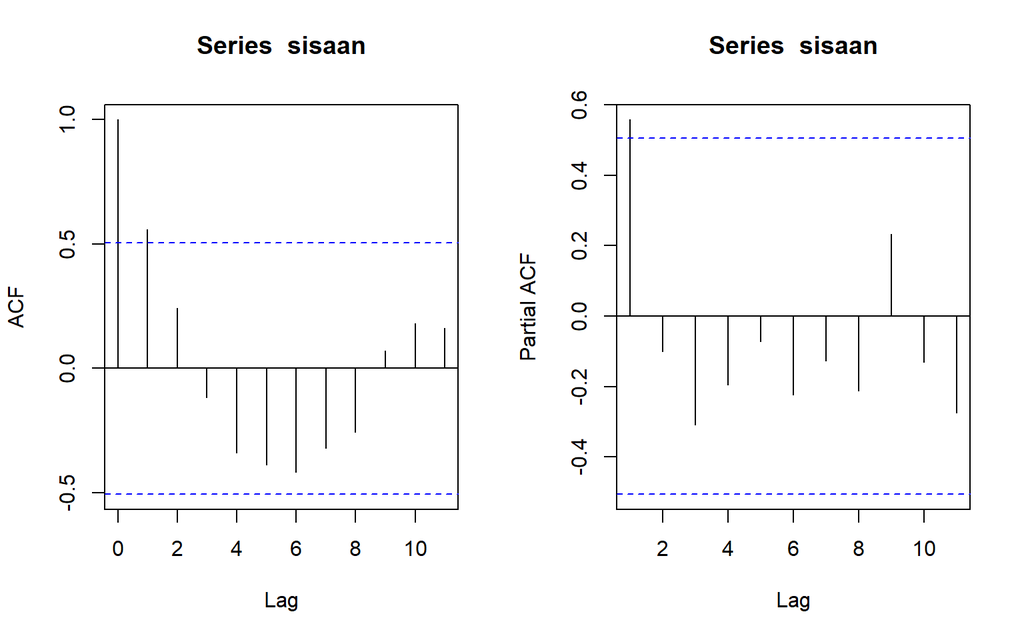

```r
#ACF dan PACF identifikasi autokorelasi
par(mfrow = c(1,2))
acf(sisaan)
pacf(sisaan)
```

Plot ACF dan PACF residual menunjukkan adanya autokorelasi yang cukup kuat pada lag 1, ditandai dengan nilai ACF positif signifikan yang melewati batas kepercayaan, sementara lag-lag berikutnya relatif lebih kecil. Pola ini mengindikasikan bahwa residual dari model regresi tidak sepenuhnya acak, melainkan masih memiliki ketergantungan antarperiode, khususnya berbentuk autokorelasi AR(1). Dengan demikian, meskipun model sudah menjelaskan hubungan utama antara IPM dan Tahun, perlu dilakukan koreksi atau penanganan autokorelasi (misalnya dengan uji Durbin-Watson, prosedur Hildreth–Lu, atau pendekatan model time series) agar hasil estimasi lebih reliabel.

```r
# Uji Durbin Watson
dwtest(modelipm)
```

```
##
##  Durbin-Watson test
##
## data:  modelipm
## DW = 0.87053, p-value = 0.00216
## alternative hypothesis: true autocorrelation is greater than 0
```

Hasil dari Durbin-Watson test menunjukkan nilai statistik sebesar 0.87053 dengan p-value sebesar 0.00216. Dari Tabel Durbin Watson diketahui nilai DL sebesar 1.0450 dan DU sebesar 1.3503, karena nilai DW < DL maka Ini mengindikasikan adanya Autokorelasi positif.

Indikasi Autokorelasi terlihat dari plot ACF & PACF serta uji Durbin Watson, sehingga diperlukan penanganan autokorelasi

# Penanganan Autokorelasi

## Metode Cochrane-Orcutt

### Perhitungan dengan Packages orcutt

```r
modelipm.orcutt <- cochrane.orcutt(modelipm)
summary(modelipm.orcutt)
```

```
## Call:
## lm(formula = IPM ~ Tahun, data = ipmbkt)
##
##                Estimate  Std. Error t value  Pr(>|t|)
## (Intercept) -803.784702   75.687120 -10.620 1.863e-07 ***
## Tahun          0.437871    0.037492  11.679 6.537e-08 ***
## ---
## Signif. codes:  0 '***' 0.001 '**' 0.01 '*' 0.05 '.' 0.1 ' ' 1
##
## Residual standard error: 0.2501 on 12 degrees of freedom
## Multiple R-squared:  0.9191 ,  Adjusted R-squared:  0.9124
## F-statistic: 136.4 on 1 and 12 DF,  p-value: < 6.537e-08
##
## Durbin-Watson statistic
## (original):    0.87053 , p-value: 2.16e-03
## (transformed): 1.82534 , p-value: 2.516e-01
```

### Perhitungan Manual

```r
# Ambil rho dari model CO yang sudah ada
rho <- modelipm.orcutt$rho
rho
```

```
## [1] 0.5576985
```

```r
# Ambil data dari ipmbkt
IPM <- ipmbkt$IPM
Tahun <- ipmbkt$Tahun

# Transformasi Manual
IPM.trans <- IPM[-1] - rho * IPM[-length(IPM)]
Tahun.trans <- Tahun[-1] - rho * Tahun[-length(Tahun)]

# Model setelah transformasi Cochrane-Orcutt manual
modelCOmanual <- lm(IPM.trans ~ Tahun.trans)
summary(modelCOmanual)
```

```
##
## Call:
## lm(formula = IPM.trans ~ Tahun.trans)
##
## Residuals:
##      Min       1Q   Median       3Q      Max
## -0.37736 -0.13457  0.04348  0.18298  0.31714
##
## Coefficients:
##               Estimate Std. Error t value Pr(>|t|)
## (Intercept) -355.51517   33.47653  -10.62 1.86e-07 ***
## Tahun.trans    0.43787    0.03749   11.68 6.54e-08 ***
## ---
## Signif. codes:  0 '***' 0.001 '**' 0.01 '*' 0.05 '.' 0.1 ' ' 1
##
## Residual standard error: 0.2501 on 12 degrees of freedom
## Multiple R-squared:  0.9191, Adjusted R-squared:  0.9124
## F-statistic: 136.4 on 1 and 12 DF,  p-value: 6.537e-08
```

```r
# Mencari penduga koefisien regresi ke persamaan awal
b0bintang <- modelCOmanual$coefficients[1]  # intercept
b1 <- modelCOmanual$coefficients[2]         # slope
b0 <- b0bintang / (1 - rho)

b0
```

```
## (Intercept)
##   -803.7847
```

```r
b1
```

```
## Tahun.trans
##   0.4378709
```

Hasil regresi dengan metode Cochrane-Orcutt menunjukkan bahwa model telah berhasil mengatasi masalah autokorelasi, terlihat dari nilai Durbin-Watson yang meningkat dari 0,87 (signifikan) menjadi 1,82 (tidak signifikan). Model yang terbentuk signifikan secara keseluruhan (F-test, p < 0,001) dengan R² sebesar 91,9%, artinya sekitar 91,9% variasi nilai IPM dapat dijelaskan oleh variabel Tahun. Koefisien regresi Tahun sebesar 0,4379 dan signifikan (p < 0,001), yang mengindikasikan bahwa setiap kenaikan satu tahun diperkirakan meningkatkan nilai IPM sebesar 0,44 poin. Dengan demikian, model regresi akhir setelah perbaikan autokorelasi dapat dituliskan sebagai:
$$\hat{Y} = -803.78 + 0.4379 \times
Tahun$$

## Metode Hildreth-Lu

```r
# Model awal
model <- lm(IPM ~ Tahun, data = ipmbkt)

# Fungsi Hildreth-Lu
hildreth.lu.func <- function(r, model){
  x <- model.matrix(model)[, -1]   # variabel prediktor (Tahun)
  y <- model.response(model.frame(model))
  n <- length(y)
  t <- 2:n

  # Transformasi Hildreth-Lu
  y <- y[t] - r * y[t - 1]
  x <- x[t] - r * x[t - 1]

  return(lm(y ~ x))
}

# Pencarian rho yang meminimumkan SSE
r <- seq(0.1, 0.9, by = 0.1)
tab <- data.frame(
  rho = r,
  SSE = sapply(r, function(i){
    deviance(hildreth.lu.func(i, model))
  })
)

round(tab, 4)
```

```
##   rho    SSE
## 1 0.1 0.9848
## 2 0.2 0.8937
## 3 0.3 0.8249
## 4 0.4 0.7785
## 5 0.5 0.7544
## 6 0.6 0.7527
## 7 0.7 0.7733
## 8 0.8 0.8163
## 9 0.9 0.8816
```

```r
#Rho optimal di sekitar 0.7
rOpt <- seq(0.5,0.8, by= 0.001)
tabOpt <- data.frame("rho" = rOpt, "SSE" = sapply(rOpt, function(i){deviance(hildreth.lu.func(i, model))}))
head(tabOpt[order(tabOpt$SSE),])
```

```
##      rho       SSE
## 59 0.558 0.7507096
## 58 0.557 0.7507100
## 60 0.559 0.7507114
## 57 0.556 0.7507127
## 61 0.560 0.7507154
## 56 0.555 0.7507176
```

Dari hasil di atas, diperoleh nilai ρ yang meminimumkan SSE adalah 0.558 dengan nilai SSE sebesar 0.7507096.

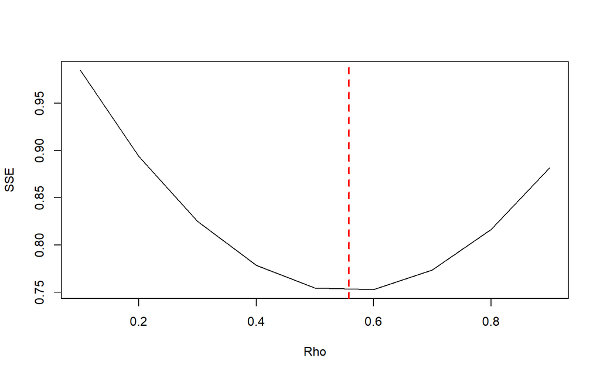

```r
#Grafik SSE optimum
par(mfrow = c(1,1))
plot(tab$SSE ~ tab$rho , type = "l", xlab = "Rho", ylab = "SSE")
abline(v = tabOpt[tabOpt$SSE==min(tabOpt$SSE),"rho"], lty = 2, col="red",lwd=2)
text(x=0.341, y=0.2397500, labels = "rho=0.558", cex = 0.8)
```

Perhitungan yang dilakukan aplikasi R menunjukkan bahwa nilai ρ optimum, yaitu saat SSE terkecil terdapat pada nilai ρ=0.558. Hal tersebut juga ditunjukkan pada plot. Selanjutnya, model dapat didapatkan dengan mengevaluasi nilai ρ ke dalam fungsi hildreth.lu.func, serta dilanjutkan dengan pengujian autokorelasi dengan uji Durbin-Watson. Namun, setelah pengecekan tersebut tidak lupa koefisien regresi tersebut digunakan untuk transformasi balik. Persamaan hasil transformasi itulah yang menjadi persamaan sesungguhnya.

```r
#Model terbaik
modelHL <- hildreth.lu.func(0.558, model)
summary(modelHL)
```

```
##
## Call:
## lm(formula = y ~ x)
##
## Residuals:
##      Min       1Q   Median       3Q      Max
## -0.37733 -0.13454  0.04338  0.18305  0.31708
##
## Coefficients:
##               Estimate Std. Error t value Pr(>|t|)
## (Intercept) -355.26832   33.47655  -10.61 1.88e-07 ***
## x              0.43787    0.03752   11.67 6.59e-08 ***
## ---
## Signif. codes:  0 '***' 0.001 '**' 0.01 '*' 0.05 '.' 0.1 ' ' 1
##
## Residual standard error: 0.2501 on 12 degrees of freedom
## Multiple R-squared:  0.919,  Adjusted R-squared:  0.9123
## F-statistic: 136.2 on 1 and 12 DF,  p-value: 6.588e-08
```

```r
#Transformasi Balik
cat("y = ", coef(modelHL)[1]/(1-0.558), "+", coef(modelHL)[2],"x", sep = "")
```

```
## y = -803.7745+0.4378658x
```

Setelah dilakukan tranformasi balik, didapatkan model dengan metode Hildreth-Lu sebagai berikut.
$$\hat{Y} =
-803.774 + 0.438 \times Tahun$$

```r
#Uji Durbin Watson
dwtest(modelHL)
```

```
##
##  Durbin-Watson test
##
## data:  modelHL
## DW = 1.8259, p-value = 0.2519
## alternative hypothesis: true autocorrelation is greater than 0
```

Hasil uji Durbin-Watson pada model Hildreth-Lu menunjukkan nilai statistik sebesar 1.8259 dengan p-value sebesar 0.2519. Sehingga autokorelasi tidak terjadi pada model ini.

# Perbandingan SSE 3 metode

```r
#Perbandingan
sseModelawal <- anova(modelipm)$`Sum Sq`[-1]
sseModelCO <- anova(modelCOmanual)$`Sum Sq`[-1]
sseModelHL <- anova(modelHL)$`Sum Sq`[-1]
mseModelawal <- sseModelawal/length(IPM)
mseModelCO <- sseModelCO/length(IPM)
mseModelHL <- sseModelHL/length(IPM)
akurasi <- matrix(c(sseModelawal,sseModelCO,sseModelHL,
                    mseModelawal,mseModelCO,mseModelHL),nrow=2,ncol=3,byrow = T)
colnames(akurasi) <- c("Model Awal", "Model Cochrane-Orcutt", "Model Hildreth-Lu")
row.names(akurasi) <- c("SSE","MSE")
akurasi
```

```
##     Model Awal Model Cochrane-Orcutt Model Hildreth-Lu
## SSE 1.11797298             0.7507095        0.75070959
## MSE 0.07453153             0.0500473        0.05004731
```

Hasil perbandingan menunjukkan bahwa model awal memiliki nilai SSE = 1.1179 dan MSE = 0.0745, yang lebih tinggi dibandingkan dengan model setelah koreksi autokorelasi. Baik metode Cochrane-Orcutt maupun Hildreth-Lu menghasilkan perbaikan signifikan dengan SSE ≈ 0.7507 dan MSE ≈ 0.0500, yang berarti terdapat penurunan galat total maupun rata-rata kuadrat. Hal ini mengindikasikan bahwa kedua metode mampu mengatasi masalah autokorelasi pada model awal, menghasilkan model yang lebih efisien dan reliabel, dengan performa hampir identik antara Cochrane-Orcutt dan Hildreth-Lu.

# Kesimpulan

Kesimpulannya, penanganan autokorelasi dengan Cochrane-Orcutt (CO) dan Hildreth-Lu (HL) sama-sama efektif karena keduanya berhasil menurunkan nilai SSE dan MSE dibandingkan model awal, yang berarti model menjadi lebih efisien dan akurat. Nilai SSE dan MSE yang dihasilkan kedua metode hampir identik, sehingga secara praktis tidak ada perbedaan signifikan dalam kinerjanya. Dengan demikian, baik metode CO maupun HL dapat digunakan untuk mengatasi autokorelasi, dan pemilihan di antara keduanya lebih didasarkan pada preferensi peneliti atau kemudahan implementasi, bukan pada hasil perbaikan model yang dihasilkan.